# ggplot2

# 8. ggplot2

We can visualize data easily and flexibly with using R. For this semester, we will use ggplot package.

```r
library(dplyr)
library(ggplot2)
```

We use ggplot2 because it’s easy to use or learn and the result of plotting would be nice. One weak point that ggplot has is ggplot is made to process tidy data frames. Therefore, we need to tidy data. Or, we can suppose that we might get a plot if the data we have is tidy.

## 8.1 The components of a graph

In ggplot2, graphs are composed of 3 main components: Data, Geometry, Aesthetic mapping.

For example on the textbook, the graph is regarding to murder of US. And the geometry of the plot is a scatterplot. Finally, the plot is using some visual cues to conveying informations like region, population, murder rate and the relationship of them and so on. We can tell about the abbreviations of points or data of both axises or something else.

We will practice ggplot2 with data `murders`

```r
library(dslabs)
data(murders)
```

## 8.2 `ggplot` objects

First, we can create `ggplot` object to plot graphs with function `ggplot`

```r
ggplot(data = murders)
```

Or,

```r
murders %>% ggplot()
```

But in this case, we only can see grey screen. Because the object is not assigned so:

```r
p <- ggplot(data = murders)
class(p)
```

```
[1] "gg"     "ggplot"
```

We can assign it to variable `p` and we can make same things by typing:

```r
print(p)
```

```r
p
```

## 8.3 Geometries

In `ggplot2` we create graphs by adding layers. When we add layers, we use `+`. In general: > DATA %>% ggplot() + LAYER 1 + LAYER 2 + … + LAYER N

In this case, we would use the function `geo_point`.

We need to provide data and a mapping for `geom_point` to run properly. We already saved `murders` to `p` and we can add layer to `p`. But at first, we should check about *Aesthetics*:

```r
?geom_point
```

we need at least two data `x` and `y`.

## 8.4 Aesthetic mappings

We should properly connect properties of data with features of the graph, we call that as ‘Aesthetic mappings’ and use the function `aes`.

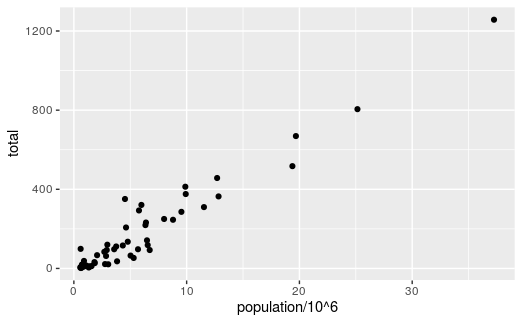

```r
murders %>% ggplot() + geom_point(aes(x = population/10^6, y = total))
```

We can find that the the object names are used as variable names. In other word, we do not need to use `$` inside of the function `aes`.

## 8.5 Layers

Now, we will add the layer of text, that is the abbreviations of each points. We will use the function `geom_label` and `geom_text`. We can add abbs with argument with the name of ‘label’:

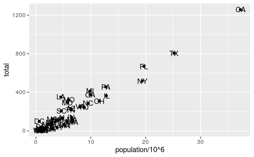

```r
p + geom_point(aes(population/10^6, total)) +
  geom_text(aes(population/10^6, total, label = abb))
```

We can find each point has abbreviation of state the point is indicating. We can rearrange codes with using `aes` and can save it to other variable:

```r
p_test <- p + geom_text(aes(population/10^6, total, label = abb))
```

### 8.5.1 Tinkering with arguments

There is so many arguments except `aes` or `data`. For example, we can adjust the size of points:

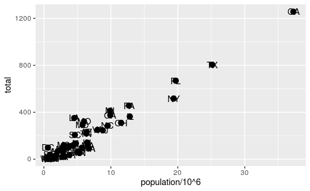

```r
p + geom_point(aes(population/10^6, total), size = 3) +
  geom_text(aes(population/10^6, total, label = abb))
```

In this case, the argument `size` is work outside of the function `aes` therefore, it is not a mapping.

Or, we can move texts to slightly side by using the argument `nudge_x`:

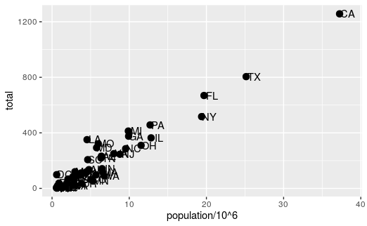

```r
p + geom_point(aes(population/10^6, total), size = 3) +
  geom_text(aes(population/10^6, total, label = abb), nudge_x = 1)
```

## 8.6 Global versus local aesthetic mappings

If we check the arguments of `ggplot`:

```r
args(ggplot)
```

```
function (data = NULL, mapping = aes(), ..., environment = parent.frame())
NULL
```

Since there is anything in `mapping`, we should set mappings everytime we plot the graph. So, we can map x and y axis:

```r
p <- murders %>% ggplot(aes(population/10^6, total, label = abb))
```

And when we want to add something to the graph:

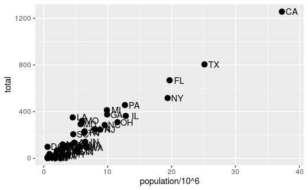

```r
p + geom_point(size = 3) +
  geom_text(nudge_x = 1.5)
```

If we put both of them into `aes` they would apply to both plots, so we define point size and text nudge respectively.

And if we use `aes` in local geometry, we can override those mappings:

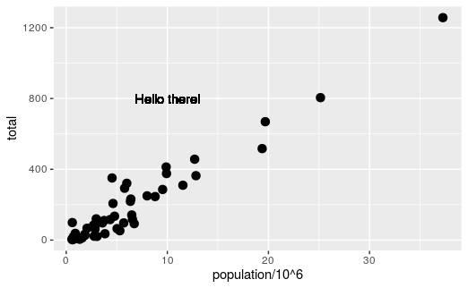

```r
p + geom_point(size = 3) +
  geom_text(aes(x = 10, y = 800, label = "Hello there!"))
```

This time, `geom_text` used `10` to `x` not `population/10^6` as well as `y`.

## 8.7 Scales

This plot has axis of real scale. We can adjust this into log-scale with using the function `scale_x_continuous`:

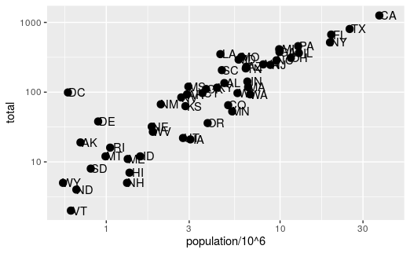

```r
p + geom_point(size = 3) +
  geom_text(nudge_x = 0.05) +
  scale_x_continuous(trans = "log10") +
  scale_y_continuous(trans = "log10")
```

In the graph, we can find the nudge has been shortened.

We can just use the function `scale_x_log10`:

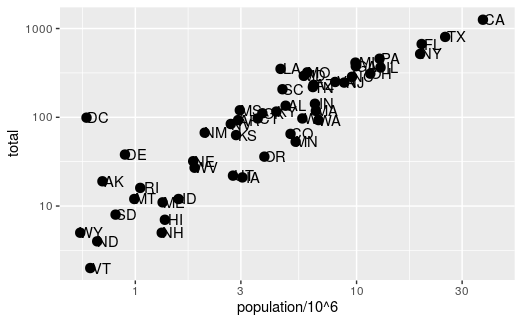

```r
p + geom_point(size = 3) +
  geom_text(nudge_x = 0.05) +
  scale_x_log10() +
  scale_y_log10()
```

## 8.8 Lables and titles

As we change the information of axis, we can adjust the lable or titles:

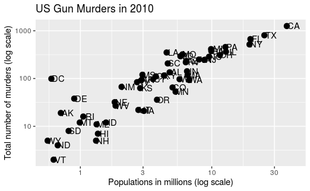

```r
p + geom_point(size = 3) +
  geom_text(nudge_x = 0.05) +
  scale_x_log10() +
  scale_y_log10() +

  xlab("Populations in millions (log scale)") +
  ylab("Total number of murders (log scale)") +

  ggtitle("US Gun Murders in 2010")
```

## 8.9 Categories as colors

The graph is too monotonous. Let`s change the color of points with using the argument`col`. First we will redefine`p`:

```r
p <-  murders %>% ggplot(aes(population/10^6, total, label = abb)) +
  geom_text(nudge_x = 0.05) +
  scale_x_log10() +
  scale_y_log10() +

  xlab("Populations in millions (log scale)") +
  ylab("Total number of murders (log scale)") +
  ggtitle("US Gun Murders in 2010")
```

Finally we can add the layer of color of points:

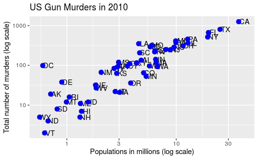

```r
p + geom_point(size = 3, color ="blue")
```

If we choose only regions not specific colors, it automatically colors the points according to region:

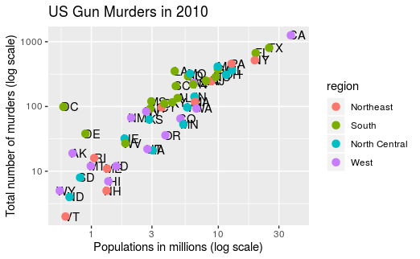

```r
p + geom_point(aes(col=region), size = 3)
```

If we do not want automatic legend, we can off with setting argument `show.legend` as `FALSE` from `geom_point`

## 8.10 Annotation, shapes, and adjustments

We can add something else. In this case, we would add the overall murder rate:

```r
r <- murders %>%
  summarize(rate = sum(total) /  sum(population) * 10^6) %>%
  pull(rate)
```

When we add a line to graph, we use the function `geom_abline`. `ab` mean intercept and slope respectively:

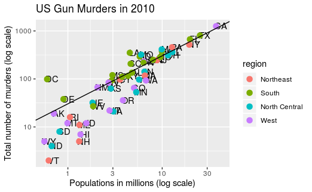

```r
p + geom_point(aes(col=region), size = 3) +
  geom_abline(intercept = log10(r))
```

As we said, the line with `geom_abline` did not use any data from objects. We can adjust the configuration of the line also.

```r
p <- p + geom_abline(intercept = log10(r), lty = 2, color = "darkgrey") +
  geom_point(aes(col=region), size = 3)
```

There is many other applications of ggplot2. For example, we can capitalize the name of legend of color.

```r
p <- p + scale_color_discrete(name = "Region")
```

## 8.11 Add-on packages

There is add-ons of ggplot2: the ggthemes and ggrepel packages.

There is default themes in ggplot package:

```r
ds_theme_set()
```

But we can change the theme of the graph made with ggplot2:

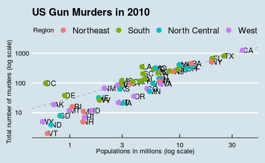

```r
# install.packages('ggthemes')
library(ggthemes)
p + theme_economist()
```

And when we use `ggrepel` we can change texts by using `geom_text_repel` instead of `geom_text`:

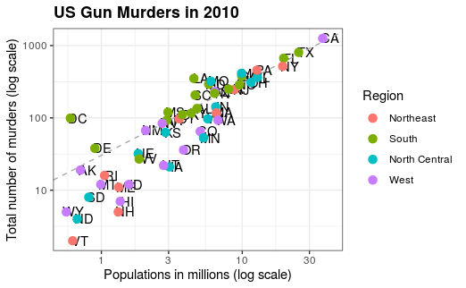

```r
# install.packages('ggrepel')
library(ggrepel)
p + geom_text_repel(nudge_x = 0.05)
```

## 8.12 Putting it all together

Finally, we can try to plot perfect graph!:

[figure not shown]

```r
library(ggthemes)
library(ggrepel)

# calculate murder rate
r <- murders %>%
  summarize(rate = sum(total) /  sum(population) * 10^6) %>%
  pull(rate)

# input data to ggplot
murders %>% ggplot(aes(population/10^6, total, label = abb)) +

  # insert overall mean murder rate line
  geom_abline(intercept = log10(r), lty = 2, color = "darkgrey") +

  # plot the points with color
  geom_point(aes(col=region), size = 3) +

  # write abbreviations of each points on side so as not to overlap one another
  geom_text_repel() +

  # adjust both axises
  scale_x_log10() +
  scale_y_log10() +
  xlab("Populations in millions (log scale)") +
  ylab("Total number of murders (log scale)") +

  # give title
  ggtitle("US Gun Murders in 2010") +

  # adjust legend
  scale_color_discrete(name = "Region") +

  # change overall theme
  theme_economist()
```

## 8.13 Quick plots with `qplot`

There is one more function to make quick plots like basic function `hist`, `plot`, `boxplot`, it`s`qplot`

For example, we have two vectors:

```r
data(murders)
x <- log10(murders$population)
y <- murders$total
```

If we use ggplot, we should merge two vectors into a data frame and use ggplot:

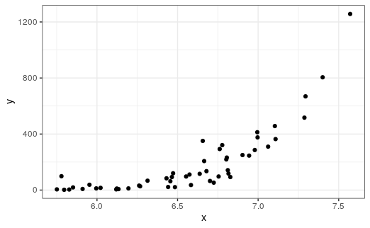

```r
data.frame(x = x, y = y) %>%
  ggplot(aes(x, y)) +
  geom_point()
```

This will not that bad but the code looks little be complicated. So we can use `qplot`:

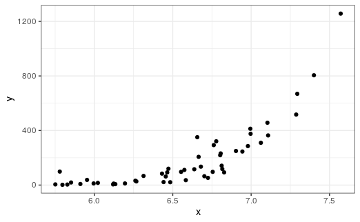

```r
qplot(x, y)
```

## 8.14 Grids of plots

We use one more package, the gridExtra

```r
# install.packages("gridExtra")
library(gridExtra)
```

This allows arrange multiple graphs at one large graph:

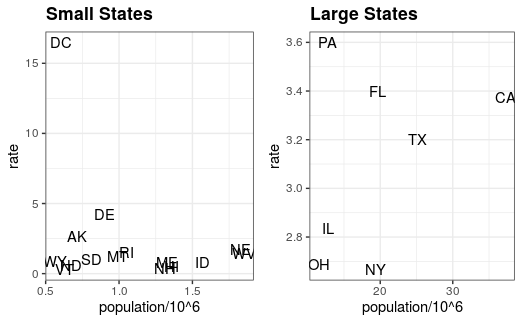

```r
p1 <- murders %>%
  mutate(rate = total/population*10^5) %>%
  filter(population < 2*10^6) %>%
  ggplot(aes(population/10^6, rate, label = abb)) +
  geom_text() +
  ggtitle("Small States")

p2 <- murders %>%
  mutate(rate = total/population*10^5) %>%
  filter(population > 10*10^6) %>%
  ggplot(aes(population/10^6, rate, label = abb)) +
  geom_text() +
  ggtitle("Large States")

grid.arrange(p1, p2, ncol = 2)
```

## 8.15 Exercises

Start by loading the dplyr and ggplot2 library as well as the `murders` and `heights` data.

```r
library(dplyr)
library(ggplot2)
library(dslabs)
data(heights)
data(murders)
```

1. With ggplot2 plots can be saved as objects. For example we can associate a dataset with a plot object like this

```r
p <- ggplot(data = murders)
```

Because `data` is the first argument we don’t need to spell it out

```r
p <- ggplot(murders)
```

and we can also use the pipe:

```r
p <- murders %>% ggplot()
```

What is class of the object `p`?

```r
class(p)
```

```
[1] "gg"     "ggplot"
```

It`s ggplot.

2. Remember that to print an object you can use the command print or simply type the object. For example

```r
x <- 2
x
```

```
[1] 2
```

```r
print(x)
```

```
[1] 2
```

Print the object `p` defined in exercise one and describe what you see.

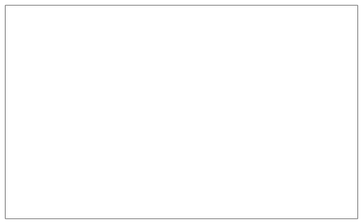

```r
print(p)
```

3. Using the pipe `%>%`, create an object `p` but this time associated with the `heights` dataset instead of the `murders` dataset.

```r
p <- heights %>% ggplot()
```

4. What is the class of the object `p` you have just created?

```r
class(p)
```

```
[1] "gg"     "ggplot"
```

It`s also a ggplot.

5. Now we are going to add a layers and the corresponding aesthetic mappings. For the murders data we plotted total murders versus population sizes. Explore the `murders` data frame to remind yourself what are the names for these two variables and select the correct answer. Hint: Look at `?murders`.

We use column `population` as the x axis and colunm `total` asthe y axis. C. `total` and `population`.

6. To create the scatter plot we add a layer with `geom_point`. The aesthetic mappings require us to define the x-axis and y-axis variables respectively. So the code looks like this:

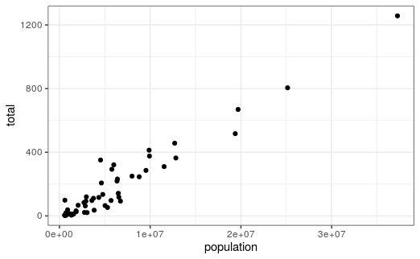

```r
murders %>% ggplot(aes(x = population, y = total)) +
  geom_point()
```

except we have to define the two variables `x` and `y`. Fill this out with the correct variable names.

7. Note that if we don’t use argument names, we can obtain the same plot by making sure we enter the variable names in the right order like this:

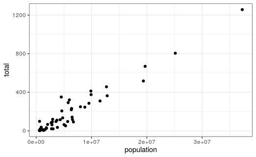

```r
murders %>% ggplot(aes(population, total)) +
  geom_point()
```

Remake the plot but now with total in the x-axis and population in the y-axis.

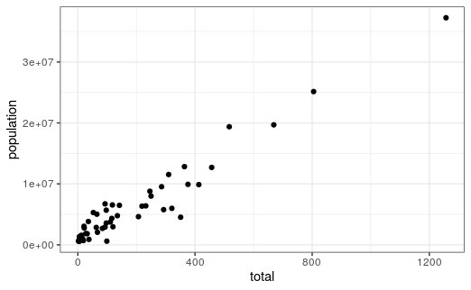

```r
murders %>% ggplot(aes(total, population)) +
  geom_point()
```

8. If instead of points we want to add text, we can use the `geom_text()` or `geom_label()` geometries. The following code

```r
murders %>% ggplot(aes(population, total)) +
  geom_label()
```

```
Error: geom_label requires the following missing aesthetics: label
```

will give us the error message: `Error: geom_label requires the following missing aesthetics: label`

Why is this?

We only connected the population and the number of murders but did not state names to ggplot, especially `aes`.

B. We need to let `geom_label` know what character to use in the plot.

9. Rewrite the code above to abbreviation as the label through `aes`

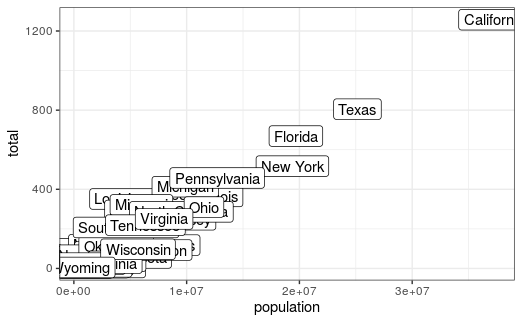

```r
murders %>% ggplot(aes(population, total, label = state)) +
  geom_label()
```

10. Change the color of the labels through blue. How will we do this?

11. Rewrite the code above to make the labels blue.

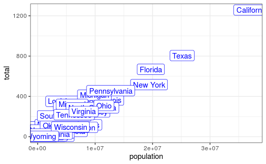

```r
murders %>% ggplot(aes(population, total, label = state)) +
  geom_label(col = 'blue')
```

12. Now suppose we want to use color to represent the different regions. In this case which of the following is most appropriate:

13. Rewrite the code above to make the labels’ color be determined by the state’s region.

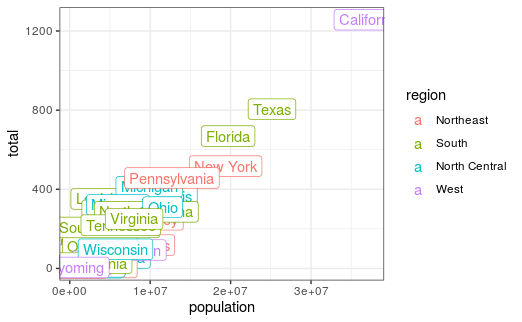

```r
murders %>% ggplot(aes(population, total, label = state, color = region)) +
  geom_label()
```

```r
p <- murders %>%
  ggplot(aes(population, total, label = abb, color = region)) +
  geom_label()
```

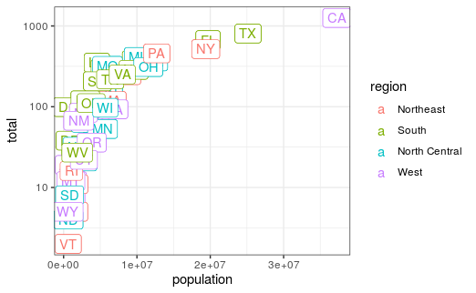

```r
p + scale_y_log10() +
  geom_label()
```

15. Repeat the previous exercise but now change both axes to be in the log scale.

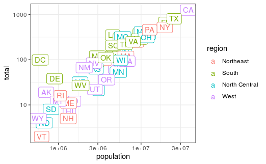

```r
p + scale_y_log10() +
  scale_x_log10() +
  geom_label()
```

16. Now edit the code above to add the title “Gun murder data” to the plot. Hint: use the `ggtitle` function.

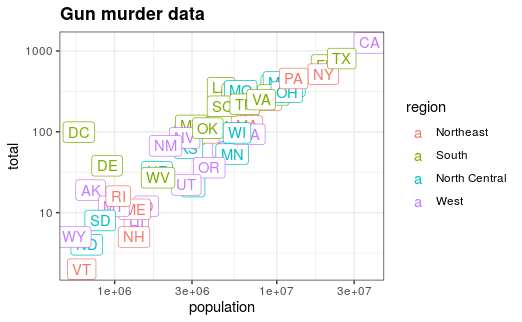

```r
murders %>%
  ggplot(aes(population, total, label = abb, color = region)) +
  scale_y_log10() +
  scale_x_log10() +

  ggtitle('Gun murder data') +
  geom_label()
```